# Homework 5: Complete

Connecticut Real Estate Sales Data

Joseph Farrell  
2022-03-09

**Load Libraries**

```r
library(readr)
library(tidyverse)
library(dplyr)
library(mosaic)
library(ggplot2)
library(lubridate)
```

**Read in data**

```r
connecticut <- read_csv("/Users/nelsonfarrell/Downloads/Real_Estate_Sales_2001-2019_GL.csv")
```

**Check variables of `connecticut`**

```r
str(connecticut)
```

```
spec_tbl_df [930,621 × 14] (S3: spec_tbl_df/tbl_df/tbl/data.frame)
 $ Serial Number   : num [1:930621] 141466 140604 14340 140455 141195 ...
 $ List Year       : num [1:930621] 2014 2014 2014 2014 2014 ...
 $ Date Recorded   : chr [1:930621] "08/06/2015" "06/29/2015" "07/01/2015" "04/30/2015" ...
 $ Town            : chr [1:930621] "Stamford" "New Haven" "Ridgefield" "New Britain" ...
 $ Address         : chr [1:930621] "83 OVERBROOK DRIVE" "56 HIGHVIEW LANE" "32 OVERLOOK DR" "171 BRADFORD WALK" ...
 $ Assessed Value  : num [1:930621] 503270 86030 351880 204680 229330 ...
 $ Sale Amount     : num [1:930621] 850000 149900 570000 261000 250000 ...
 $ Sales Ratio     : num [1:930621] 0.592 0.574 0.617 0.784 0.917 ...
 $ Property Type   : chr [1:930621] "Residential" "Residential" "Residential" "Residential" ...
 $ Residential Type: chr [1:930621] "Single Family" "Single Family" "Single Family" "Condo" ...
 $ Non Use Code    : chr [1:930621] NA NA NA NA ...
 $ Assessor Remarks: chr [1:930621] NA NA NA NA ...
 $ OPM remarks     : chr [1:930621] NA NA NA NA ...
 $ Location        : chr [1:930621] "POINT (-73.525969 41.081897)" "POINT (-72.878115 41.30285)" "POINT (-73.508273 41.286223)" "POINT (-72.775592 41.713335)" ...
 - attr(*, "spec")=
  .. cols(
  ..   `Serial Number` = col_double(),
  ..   `List Year` = col_double(),
  ..   `Date Recorded` = col_character(),
  ..   Town = col_character(),
  ..   Address = col_character(),
  ..   `Assessed Value` = col_double(),
  ..   `Sale Amount` = col_double(),
  ..   `Sales Ratio` = col_double(),
  ..   `Property Type` = col_character(),
  ..   `Residential Type` = col_character(),
  ..   `Non Use Code` = col_character(),
  ..   `Assessor Remarks` = col_character(),
  ..   `OPM remarks` = col_character(),
  ..   Location = col_character()
  .. )
 - attr(*, "problems")=<externalptr>
```

**Remove columns `Serial number`, `Non Use Code`, `Assessor Remarks`, `Sales Ratio`, and `OPM Remarks`**

```r
connecticut <- select(connecticut,
                      "List Year",
                      "Date Recorded",
                      "Town",
                      "Assessed Value",
                      "Sale Amount",
                      "Property Type",
                      "Residential Type",
                      "Location")
head(connecticut) #view first 6 rows of `connecticut`
```

```
# A tibble: 6 × 8
  `List Year` `Date Recorded` Town      `Assessed Value` `Sale Amount`
        <dbl> <chr>           <chr>                <dbl>         <dbl>
1        2014 08/06/2015      Stamford            503270        850000
2        2014 06/29/2015      New Haven            86030        149900
3        2014 07/01/2015      Ridgefie…           351880        570000
4        2014 04/30/2015      New Brit…           204680        261000
5        2014 06/26/2015      Stamford            229330        250000
6        2014 06/29/2015      West Har…           356300        600000
# … with 3 more variables: `Property Type` <chr>,
#   `Residential Type` <chr>, Location <chr>
```

- These removed columns do not appear to be essential to the analysis

**View counts of `Property Type` and `Residential Type`**

```r
connecticut %>%
  count(`Property Type`)
```

```
# A tibble: 18 × 2
   `Property Type`      n
   <chr>            <int>
 1 A                 2210
 2 Apartments        2922
 3 C                    3
 4 C/I/U            11913
 5 Commercial       19404
 6 Condo             9932
 7 Four Family        237
 8 Industrial        2551
 9 Public Utility      66
10 R               290287
11 Residential     494147
12 Single Family    40518
13 Three Family      1228
14 Two Family        2411
15 UA                  11
16 V                24479
17 Vacant Land      23414
18 <NA>              4888
```

```r
connecticut %>%
  count(`Residential Type`)
```

```
# A tibble: 6 × 2
  `Residential Type`      n
  <chr>               <int>
1 Condo              105420
2 Four Family          2150
3 Single Family      401612
4 Three Family        12586
5 Two Family          26408
6 <NA>               382445
```

- After looking at the counts of `Property Type` and `Residential Type`, it appears that looking at only residential properties (including different types) will be most revealing so I will remove `Property Type` and filter out all the NAs (which would be non-residential properties) from `Residential Type`.

**Remove `Property Type` Column**

```r
connecticut <- select(connecticut,
                      "List Year",
                      "Date Recorded",
                      "Town",
                      "Assessed Value",
                      "Sale Amount",
                      "Residential Type",
                      "Location")
```

```r
connecticut <- connecticut %>%
  na.omit(`Residential Type`)
connecticut %>%
  count(`Residential Type`)
```

```
# A tibble: 5 × 2
  `Residential Type`      n
  <chr>               <int>
1 Condo               76907
2 Four Family          1690
3 Single Family      303731
4 Three Family        10194
5 Two Family          21184
```

- Here I am just looking how many observations there are for each `residential_type`

**Rename columns without spaces and for clarity**

```r
connecticut <- rename(connecticut,
                      "list_year" = "List Year",
                      "sale_date" = "Date Recorded",
                      "assessed_price" = "Assessed Value",
                      "sale_price" = "Sale Amount",
                      "residential_type" = "Residential Type",
                      "location" = "Location",
                      "town" = "Town")
```

**List and description of remaining variables**

- `list_year`: numeric, year the property was listed
- `sale_date`: Date, date the property was sold
- `assessed_price`: numeric, price used in tax evaluation
- `sale_price`: numeric, price the property sold for
- `residential_type`: character, nominal, if residential, type of residential (i.e., single family, two family, etc.)
- `location`: character, nominal, location of property in lat./long. (maybe useful to create a map later)
- `town`: character, nominal, town location property

**Potential Research Questions**

- Where are property values the highest?
- Where are property values the lowest?
- Where are property values increasing/decreasing?
- Are some areas trending higher while others trending lower?
- Are different types of property increasing/decreasing at different rates?
- Where should one buy a property and of what type to maximize increasing property value?

**Explore Data**

```r
head(connecticut)
```

```
# A tibble: 6 × 7
  list_year sale_date town  assessed_price sale_price residential_type
      <dbl> <chr>     <chr>          <dbl>      <dbl> <chr>
1      2014 08/06/20… Stam…         503270     850000 Single Family
2      2014 06/29/20… New …          86030     149900 Single Family
3      2014 07/01/20… Ridg…         351880     570000 Single Family
4      2014 04/30/20… New …         204680     261000 Condo
5      2014 06/26/20… Stam…         229330     250000 Single Family
6      2014 06/29/20… West…         356300     600000 Single Family
# … with 1 more variable: location <chr>
```

```r
tail(connecticut)
```

```
# A tibble: 6 × 7
  list_year sale_date town  assessed_price sale_price residential_type
      <dbl> <chr>     <chr>          <dbl>      <dbl> <chr>
1      2014 03/31/20… Litc…         220250     310000 Single Family
2      2014 02/19/20… Hamd…         220080     402500 Single Family
3      2014 12/18/20… Danb…         248500     428000 Single Family
4      2014 11/20/20… Naug…         175910     252500 Single Family
5      2014 06/18/20… Madi…         409200     580000 Single Family
6      2014 04/22/20… Ches…         379100     520000 Condo
# … with 1 more variable: location <chr>
```

**Convert `sale_date` from character to date and create new column `year`**

```r
connecticut$sale_date <- as_date(connecticut$sale_date,
                                 format = "%m/%d/%Y")
connecticut <- connecticut %>%
  mutate(year = floor_date(sale_date,
                      unit = "year"))
str(connecticut)
```

```
tibble [413,706 × 8] (S3: tbl_df/tbl/data.frame)
 $ list_year       : num [1:413706] 2014 2014 2014 2014 2014 ...
 $ sale_date       : Date[1:413706], format: "2015-08-06" ...
 $ town            : chr [1:413706] "Stamford" "New Haven" "Ridgefield" "New Britain" ...
 $ assessed_price  : num [1:413706] 503270 86030 351880 204680 229330 ...
 $ sale_price      : num [1:413706] 850000 149900 570000 261000 250000 ...
 $ residential_type: chr [1:413706] "Single Family" "Single Family" "Single Family" "Condo" ...
 $ location        : chr [1:413706] "POINT (-73.525969 41.081897)" "POINT (-72.878115 41.30285)" "POINT (-73.508273 41.286223)" "POINT (-72.775592 41.713335)" ...
 $ year            : Date[1:413706], format: "2015-01-01" ...
 - attr(*, "na.action")= 'omit' Named int [1:516915] 9 13 17 18 19 25 27 28 33 42 ...
  ..- attr(*, "names")= chr [1:516915] "9" "13" "17" "18" ...
```

**Examine first and last 75 rows of `connecticut`**

```r
head(connecticut, n = 75)
```

```
# A tibble: 75 × 8
   list_year sale_date  town          assessed_price sale_price
       <dbl> <date>     <chr>                  <dbl>      <dbl>
 1      2014 2015-08-06 Stamford              503270     850000
 2      2014 2015-06-29 New Haven              86030     149900
 3      2014 2015-07-01 Ridgefield            351880     570000
 4      2014 2015-04-30 New Britain           204680     261000
 5      2014 2015-06-26 Stamford              229330     250000
 6      2014 2015-06-29 West Hartford         356300     600000
 7      2014 2014-10-17 Willington            236060     332900
 8      2014 2015-08-05 Trumbull              183900     240000
 9      2014 2014-12-02 Waterbury              75840      91000
10      2014 2015-07-01 Trumbull              178500     175000
# … with 65 more rows, and 3 more variables: residential_type <chr>,
#   location <chr>, year <date>
```

```r
tail(connecticut, n = 75)
```

```
# A tibble: 75 × 8
   list_year sale_date  town          assessed_price sale_price
       <dbl> <date>     <chr>                  <dbl>      <dbl>
 1      2014 2015-06-02 Danbury               205900     382000
 2      2014 2014-12-23 Easton                314300     536000
 3      2014 2015-06-12 Colchester            210600     301800
 4      2014 2015-06-04 Madison               451000     549000
 5      2014 2014-10-15 Enfield               159720     121000
 6      2014 2015-07-21 Danbury               203300     305000
 7      2014 2015-07-07 Darien                677530     850000
 8      2014 2015-04-29 East Hartford         103980     170000
 9      2014 2015-06-12 Ellington             252780     378500
10      2014 2015-04-28 Hartford               12027      25090
# … with 65 more rows, and 3 more variables: residential_type <chr>,
#   location <chr>, year <date>
```

**Get summary statistics of `assessed_price` and `sale_price`**

```r
summarize(connecticut,
          mean_assessed_price = mean(assessed_price),
          mean_sale_price = mean(sale_price),
          median_assessed_price = median(assessed_price),
          median_sale_price = median(sale_price),
          sd_assessed_price =sd(assessed_price),
          sd_sale_price = sd(sale_price))
```

```
# A tibble: 1 × 6
  mean_assessed_pri… mean_sale_price median_assessed… median_sale_pri…
               <dbl>           <dbl>            <dbl>            <dbl>
1            243300.         339122.           159900           229000
# … with 2 more variables: sd_assessed_price <dbl>,
#   sd_sale_price <dbl>
```

**View favstats of `assessed_price`**

```r
favstats(~assessed_price, data = connecticut)
```

```
 min     Q1 median     Q3       max     mean      sd      n missing
   0 111440 159900 245980 881510000 243299.8 1457126 413706       0
```

**View favstats of `sale_price`**

```r
options(scipen = 999) # remove scientific notation
favstats(~sale_price, data = connecticut)
```

```
 min     Q1 median     Q3       max     mean     sd      n missing
   0 148000 229000 358500 120000000 339121.6 608770 413706       0
```

**Examine counts of `residential_type`**

```r
table(select(connecticut, residential_type))
```

```
        Condo   Four Family Single Family  Three Family    Two Family
        76907          1690        303731         10194         21184
```

```r
connecticut %>%
  count(residential_type)
```

```
# A tibble: 5 × 2
  residential_type      n
  <chr>             <int>
1 Condo             76907
2 Four Family        1690
3 Single Family    303731
4 Three Family      10194
5 Two Family        21184
```

**View proportions of `residential_type`**

```r
prop.table(table(select(connecticut, residential_type)))
```

```
        Condo   Four Family Single Family  Three Family    Two Family
  0.185897715   0.004085027   0.734171126   0.024640687   0.051205445
```

**View counts of `town` variable**

```r
connecticut %>%
  count(town) %>%
  arrange(desc(n))
```

```
# A tibble: 169 × 2
   town              n
   <chr>         <int>
 1 Bridgeport    15673
 2 Waterbury     12509
 3 Stamford      11776
 4 Norwalk        9701
 5 Fairfield      8878
 6 Hamden         8746
 7 New Haven      8362
 8 West Hartford  8346
 9 Danbury        8120
10 Milford        7926
# … with 159 more rows
```

**View proportions of `town` variable**

```r
options(scipen = 999) #remove scientific notation
prop.table(table(select(connecticut, town)))
```

```
   ***Unknown***          Andover          Ansonia          Ashford
  0.000002417175   0.000807336611   0.004481443344   0.001053888510
            Avon      Barkhamsted     Beacon Falls           Berlin
  0.006492533345   0.000787999207   0.001899899929   0.007208017288
         Bethany           Bethel        Bethlehem       Bloomfield
  0.001629176275   0.007169342480   0.000872600349   0.006485281818
          Bolton           Bozrah         Branford       Bridgeport
  0.001522820554   0.000570453414   0.009086162637   0.037884391331
     Bridgewater          Bristol       Brookfield         Brooklyn
  0.000601876695   0.018525232895   0.006098533741   0.003014217826
      Burlington           Canaan       Canterbury           Canton
  0.003400965903   0.000352907620   0.001317360638   0.003676523908
         Chaplin         Cheshire          Chester          Clinton
  0.000563201887   0.008846862265   0.001123986599   0.005448313537
      Colchester        Colebrook         Columbia         Cornwall
  0.004508032274   0.000464097693   0.001588084292   0.000352907620
        Coventry         Cromwell          Danbury           Darien
  0.004237308620   0.005242853621   0.019627464915   0.008092703514
      Deep River            Derby           Durham      East Granby
  0.001588084292   0.003149579653   0.002296316708   0.002359163271
     East Haddam     East Hampton    East Hartford       East Haven
  0.001723446119   0.005564337960   0.017481013087   0.009939425582
       East Lyme     East Windsor         Eastford           Easton
  0.003604008644   0.002651641504   0.000345656094   0.002982794545
       Ellington          Enfield            Essex        Fairfield
  0.005312951710   0.012397693048   0.002032844580   0.021459683930
      Farmington         Franklin      Glastonbury           Goshen
  0.007210434463   0.000423005709   0.013415323926   0.001467225518
          Granby        Greenwich         Griswold           Groton
  0.003558082310   0.011732969790   0.003526659028   0.007019477600
        Guilford           Haddam           Hamden          Hampton
  0.007785722228   0.001051471335   0.021140616766   0.000493103798
        Hartford         Hartland        Harwinton           Hebron
  0.015513432244   0.000464097693   0.001580832765   0.001600170169
            Kent        Killingly     Killingworth          Lebanon
  0.001237593847   0.006581968838   0.002223801444   0.002337408691
         Ledyard           Lisbon       Litchfield             Lyme
  0.003113322021   0.001177164460   0.001950660614   0.000894354928
         Madison       Manchester        Mansfield      Marlborough
  0.006934876458   0.016025873446   0.004172044882   0.002117445722
```

[output cut: 31 more lines]

```
  0.001464808342   0.004128535723   0.013623201017   0.011111755691
           Union           Vernon        Voluntown      Wallingford
  0.000183705337   0.008672825630   0.000870183174   0.015779321547
          Warren       Washington        Waterbury        Waterford
  0.000505189676   0.001515569027   0.030236448106   0.005919662756
       Watertown    West Hartford       West Haven        Westbrook
  0.005320203236   0.020173746574   0.012922220127   0.002521114028
          Weston         Westport     Wethersfield       Willington
  0.003342953692   0.010894209898   0.008112040918   0.001097397669
          Wilton       Winchester          Windham          Windsor
  0.005233184919   0.003432389185   0.002146451828   0.008887954248
   Windsor Locks          Wolcott       Woodbridge         Woodbury
  0.004524952503   0.005001136072   0.002936868211   0.003052892634
       Woodstock
  0.002516279677
```

**View summary statistics of different `residential_types`**

```r
connecticut %>%
  group_by(residential_type) %>%
  summarize(mean_sale_price_type = mean(sale_price),
            median_sale_price_type = median(sale_price),
            sd_sale_price_type = sd(sale_price))
```

```
# A tibble: 5 × 4
  residential_type mean_sale_price_… median_sale_pri… sd_sale_price_t…
  <chr>                        <dbl>            <dbl>            <dbl>
1 Condo                      255460.           175000          612254.
2 Four Family                244174.           190000          382695.
3 Single Family              376150.           250000          631711.
4 Three Family               180494.           155000          165494.
5 Two Family                 195847.           163500          227566.
```

**View distribution of `sale price`, check for outliers**

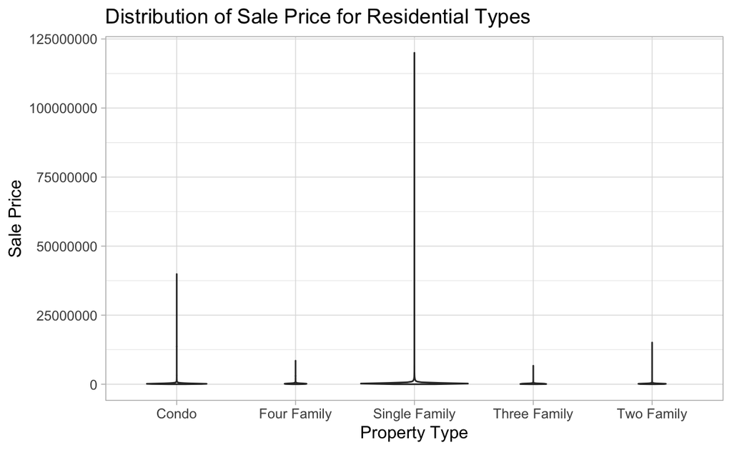

```r
connecticut %>%
  group_by(residential_type) %>%
  ggplot(aes(x = residential_type,
             y = sale_price)) +
  geom_violin(notch = TRUE) +
  labs(title = "Distribution of Sale Price for Residential Types",
       x = "Property Type",
       y = "Sale Price") +
  theme_light()
```

- The violin plots reveal that the data is heavily skewed to the right.
- The summary statistics reveal very high standard deviations, and medians and means that are not close in value.
- For these reasons I will effectively use trimmed mean as a measure of central tendency but I will actually remove the highest and lowest 2.5% of observations (sale_price).

**Remove top and bottom 2.5% of `sale_price`**

```r
connecticut <- connecticut %>%
  filter(sale_price < quantile(connecticut$sale_price, .975) &
           sale_price > quantile(connecticut$sale_price, .025))
```

**View distribution after trimming the top and bottom 2.5%**

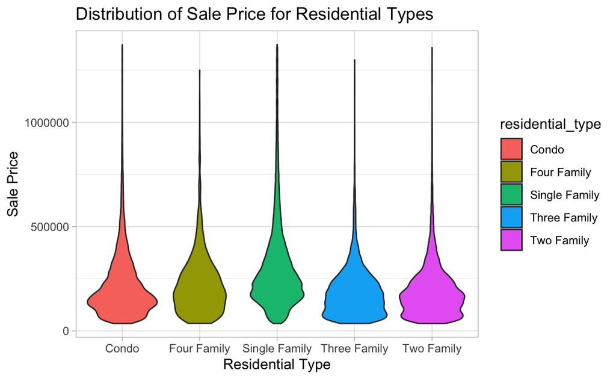

```r
connecticut %>%
  group_by(residential_type) %>%
  ggplot(aes(x = residential_type,
             y = sale_price)) +
  geom_violin(aes(fill = residential_type), notch = TRUE) +
  labs(title = "Distribution of Sale Price for Residential Types",
       x = "Residential Type",
       y = "Sale Price") +
  theme_light()
```

**Create histogram to get another view of distribution of `sale_price`**

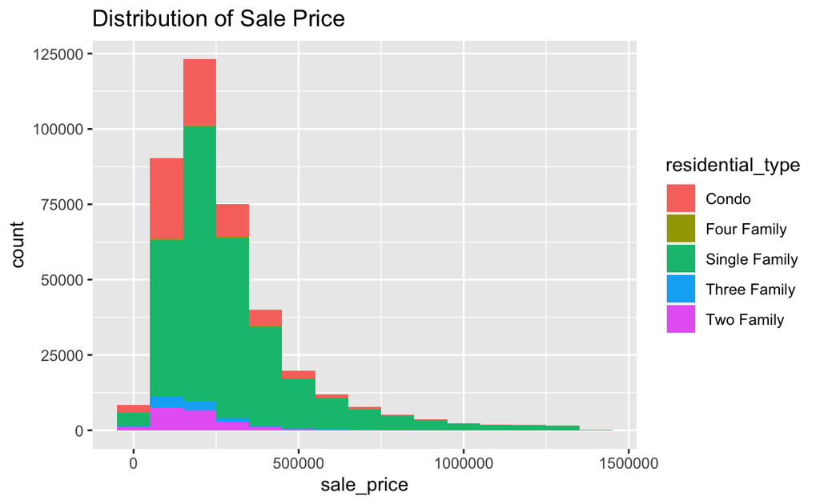

```r
connecticut %>%
  ggplot(aes(x=sale_price, fill = residential_type)) +
    geom_histogram(binwidth = 100000) +
    labs(title = "Distribution of Sale Price",
         ylab = "Count",
         xlab = "Sale Price")
```

**Counts of `sale_price` facet wrapped by `residential_type`**

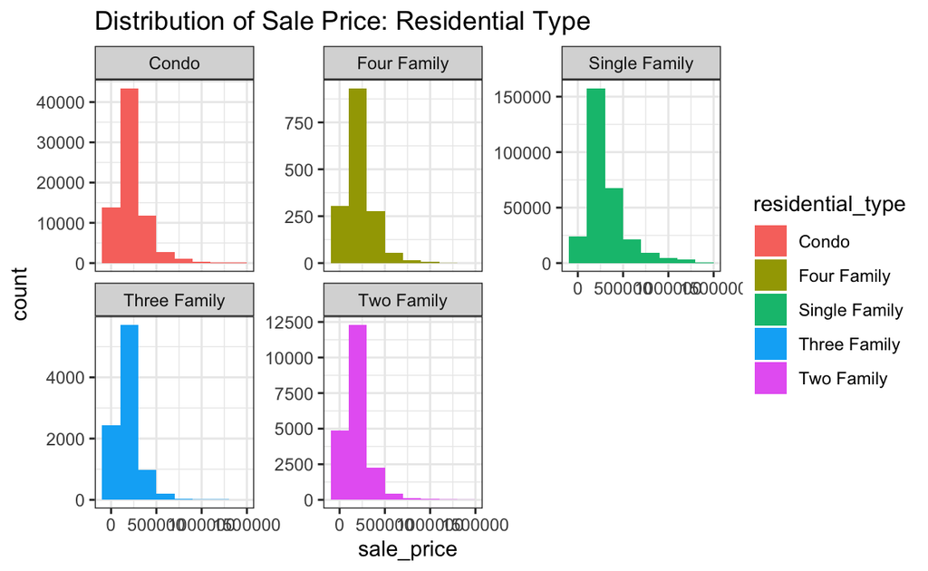

```r
connecticut %>%
  ggplot(aes(x=sale_price, fill = residential_type)) +
    geom_histogram(binwidth = 200000) +
    labs(title = "Distribution of Sale Price: Residential Type",
         ylab = "Count",
         xlab = "Sale Price") +
    theme_bw() +
    facet_wrap(vars(residential_type),
               scales = "free_y",
                        "free_x")
```

- These graphics display a distribution that is still skewed to the right but that is more normally distributed than it was prior to being trimmed.

**View favstats of `sale_price` after being trimmed**

```r
favstats(~sale_price, data = connecticut)
```

```
   min     Q1 median     Q3     max     mean       sd      n missing
 35001 150000 229000 350000 1374000 283812.3 208105.4 392896       0
```

- Here we see that standard has been reduced from $608,700 to $208,105.4 indicating that the dispersion has been decreased.
- The mean reduced from $339,121.6 to $283,812.3 and is now closer to the median.
- The minimum has increased from $0 to $35,001, and the maximum has decreased from $120,000,000 to $1,374,000 indicating the removal of at least some the most extreme outliers.

**Create a bargraph of mean `sale price` of each town in Connecticut trimmed another 10%**

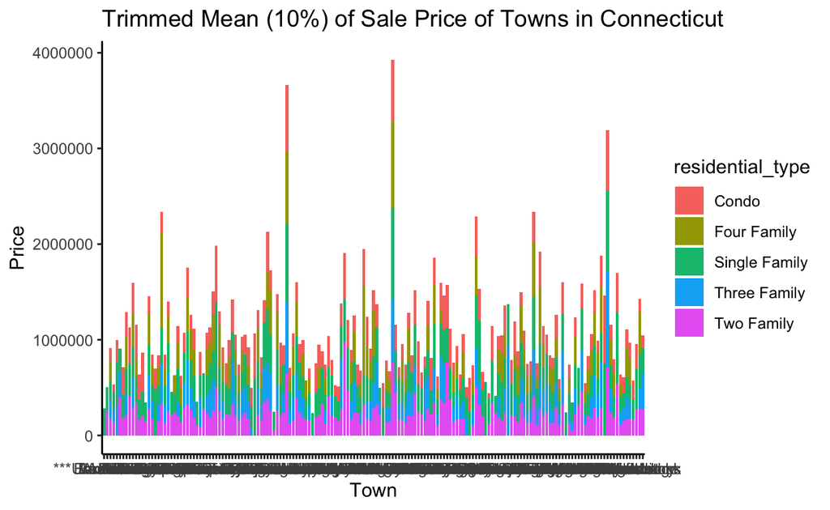

```r
connecticut %>%
  group_by(town, residential_type) %>%
  summarize(trimmed_mean_10 = mean(sale_price, trim = .1)) %>%
  ggplot(aes(x = town, y = trimmed_mean_10, fill = residential_type)) +
  geom_bar(stat = "identity") +
  labs(title = "Trimmed Mean (10%) of Sale Price of Towns in Connecticut",
       y = "Price",
       x = "Town") +
  theme_classic()
```

**Group by year and display mean sale price**

```r
connecticut %>%
  group_by(year) %>%
  summarize(mean_year = mean(sale_price)) %>%
  arrange()
```

```
# A tibble: 18 × 2
   year       mean_year
   <date>         <dbl>
 1 2001-01-01   480542.
 2 2004-01-01   458225
 3 2005-01-01   180333.
 4 2006-01-01   313608.
 5 2007-01-01   328287.
 6 2008-01-01   295805.
 7 2009-01-01   268327.
 8 2010-01-01   282171.
 9 2011-01-01   275290.
10 2012-01-01   287261.
11 2013-01-01   280918.
12 2014-01-01   270095.
13 2015-01-01   276110.
14 2016-01-01   270123.
15 2017-01-01   283867.
16 2018-01-01   274166.
17 2019-01-01   272908.
18 2020-01-01   307886.
```

```r
connecticut %>%
  group_by(sale_date, year) %>%
  arrange(sale_date)
```

```
# A tibble: 392,896 × 8
# Groups:   sale_date, year [4,137]
   list_year sale_date  town          assessed_price sale_price
       <dbl> <date>     <chr>                  <dbl>      <dbl>
 1      2017 2001-08-01 Shelton               390810     635000
 2      2017 2001-08-23 Shelton               427910     558000
 3      2006 2001-09-05 Newington             166110     256000
 4      2006 2001-09-25 Naugatuck             183850     293711
 5      2006 2001-10-27 Greenwich             573930     660000
 6      2006 2004-07-27 South Windsor         113580     210000
 7      2006 2004-08-02 Stratford              92750     179000
 8      2006 2004-09-24 South Windsor         123520     243900
 9      2007 2004-11-02 Westport              869600    1200000
10      2007 2005-02-05 Meriden               155340     264000
# … with 392,886 more rows, and 3 more variables:
#   residential_type <chr>, location <chr>, year <date>
```

- After looking at the data grouped by year, there are only a couple observations for the years 2001, 2004, and 2005. The data really begins in 2006 so I will filter out everything before 2006.

**Filter out all sale dates prior to 2006**

```r
connecticut <-connecticut %>%
  filter(sale_date >= as.Date("2005-12-31"))
```

## Creating Line Graph

**Create an object of the towns with bottom five mean sale prices**

```r
mean_bottom_5 <-connecticut %>%
  group_by(town) %>%
  summarize(mean_bottom_5 = mean(sale_price)) %>%
  arrange(mean_bottom_5) %>%
  slice(1:5)
```

**Create an object of the towns with the top five mean sale prices**

```r
mean_top_5 <-connecticut %>%
  group_by(town) %>%
  summarize(mean_top_5 = mean(sale_price)) %>%
  arrange(desc(mean_top_5)) %>%
  slice(1:5)
```

```r
mean_bottom_5
```

```
# A tibble: 5 × 2
  town          mean_bottom_5
  <chr>                 <dbl>
1 Waterbury           114718.
2 Torrington          140221.
3 New Britain         140224.
4 Norwich             143596.
5 East Hartford       144837.
```

```r
mean_top_5
```

```
# A tibble: 5 × 2
  town       mean_top_5
  <chr>           <dbl>
1 Darien        867241.
2 New Canaan    856889.
3 Westport      820937.
4 Greenwich     762582.
5 Weston        758676.
```

**Create Vector of top 5 towns**

```r
top_5 <- mean_top_5$town
```

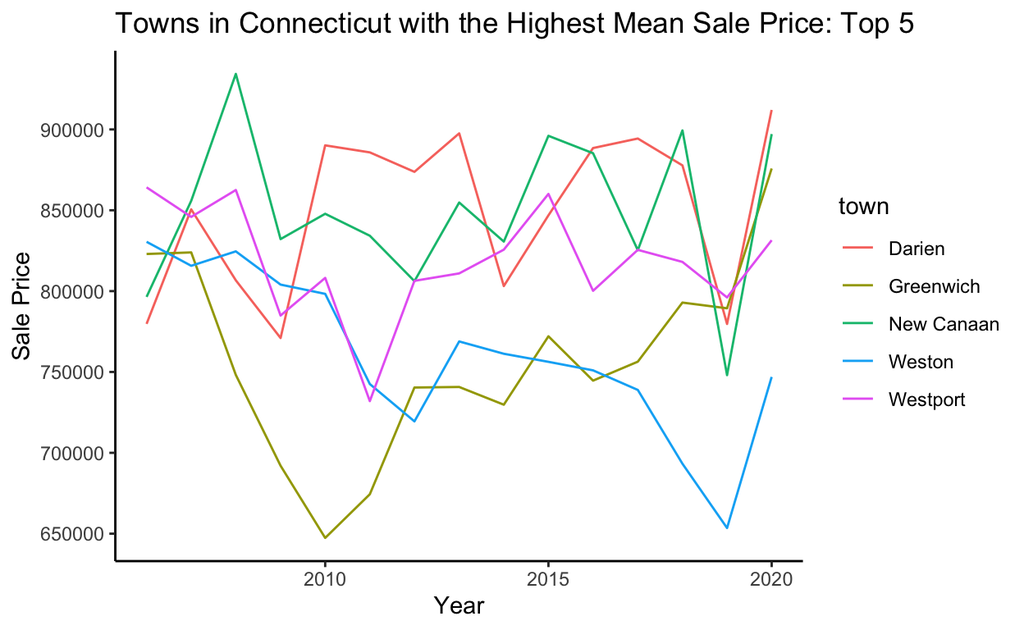

```r
connecticut %>%
  group_by(town, year) %>%
  summarize(mean_year = mean(sale_price)) %>%
  filter(town %in% top_5) %>%
  ggplot(aes(x = year, y = mean_year)) +
  geom_line(aes(color = town)) +
  ggtitle("Towns in Connecticut with the Highest Mean Sale Price: Top 5") +
  ylab("Sale Price") +
  xlab("Year") +
  theme_classic()
```

**Same as above, facet wrapped with geom_smooth**

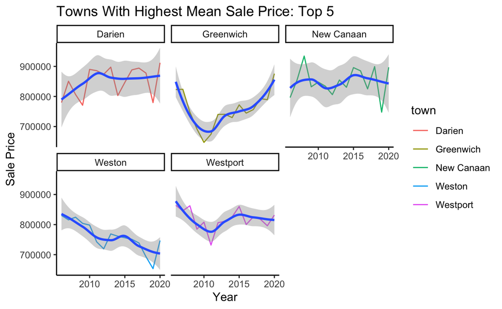

```r
connecticut %>%
  group_by(town, year) %>%
  summarize(mean_year = mean(sale_price)) %>%
  filter(town %in% top_5) %>%
  ggplot(aes(x = year, y = mean_year)) +
  geom_line(aes(color = town)) +
  geom_smooth() +
  ggtitle("Towns With Highest Mean Sale Price: Top 5") +
  ylab("Sale Price") +
  xlab("Year") +
  theme_classic() +
  facet_wrap(vars(town))
```

- This graphic gives us a better idea of how the mean sale price is behaving in these specific towns.
  - It shows us that the Greenwich mean sale price appears to be increasing
  - It shows us that the Weston mean sale price is decreasing
- Limitations:
  - This graphic doesn’t really get us any closer to answering the overarching research questions.
  - Where are property values increasing?
  - What types of property are the values increasing.

## Scatterplot

**Create scatterplot of `mean_monthly_sale_price` grouped by `residential_type`**

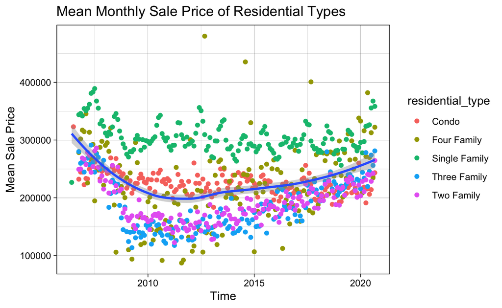

```r
connecticut %>%
  group_by(residential_type, month = lubridate::floor_date(sale_date, "month")) %>%
  summarize(mean_monthy_sale_price = mean(sale_price)) %>%
  ggplot(aes(x = month, y = mean_monthy_sale_price)) +
  geom_point((aes(color = residential_type))) +
  geom_smooth() +
  ggtitle("Mean Monthly Sale Price of Residential Types") +
  ylab("Mean Sale Price") +
  xlab("Time") +
  theme_linedraw()
```

**Scatterplot of yearly mean sale price for each `residential_type` with confidence intervals and regression line**

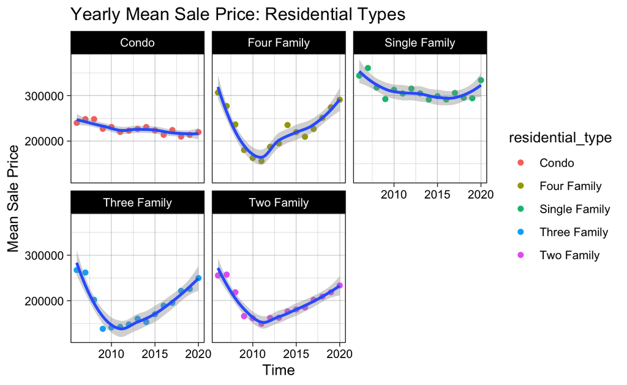

```r
connecticut %>%
  group_by(residential_type, year) %>%
  summarize(mean_year_type = mean(sale_price)) %>%
  ggplot(aes(x = year, y = mean_year_type)) +
  geom_point((aes(color = residential_type))) +
  geom_smooth() +
  ggtitle("Yearly Mean Sale Price: Residential Types") +
  ylab("Mean Sale Price") +
  xlab("Time") +
  theme_linedraw() +
  facet_wrap(vars(residential_type))
```

- This graphic demonstrates the behavior of the mean sale price of the different `residential_types`.
- The graphic shows that multi-unit properties appear to be increasing in value faster than single family properties (i.e. condo and single family), overall.
- Four-family properties appear to be increasing the fastest, but as displayed earlier, four family properties represent the smallest data set, with only 1690 total observations.

## Mapping

**Read in map data and view Connecticut map**

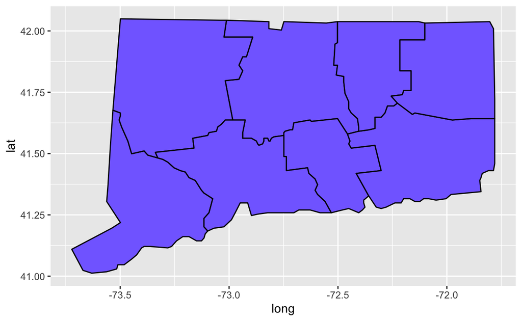

```r
con_map <- map_data("county",
         "connecticut")
ggplot() +
  geom_polygon(data = con_map,
               aes(x = long, y = lat, group = group),
               color = "black", fill = "slateblue1")
```

**Read in data frame containing Connecticut town and county data**

```r
county_town <- read_csv(("/Users/nelsonfarrell/Documents/501 Stats/Connecticut County:Towns.csv"))
county_town <- county_town %>%
  select("subregion", "town")
```

**Create object `mapping`: Joining `connecticut` and `county_town` data**

```r
mapping <-
  left_join(connecticut, county_town, by = "town") %>%
  group_by(subregion) %>%
  summarize(county_mean = mean(sale_price))
mapping
```

```
# A tibble: 9 × 2
  subregion  county_mean
  <chr>            <dbl>
1 fairfield      419357.
2 hartford       235023.
3 litchfield     253131.
4 middlesex      276324.
5 new haven      237101.
6 new london     233944.
7 tolland        233742.
8 windham        189834.
9 <NA>           282450
```

**Join `mapping` object with `con_map` data**

```r
mapping <- inner_join(mapping, con_map, by = "subregion")
```

**Create object to use when labeling the counties on the map**

```r
county_names <- aggregate(cbind(long, lat) ~ subregion, data=mapping,
                    FUN=function(x)mean(range(x)))
```

**Create map of Connecticut counties displaying the mean sale price of residential properties**

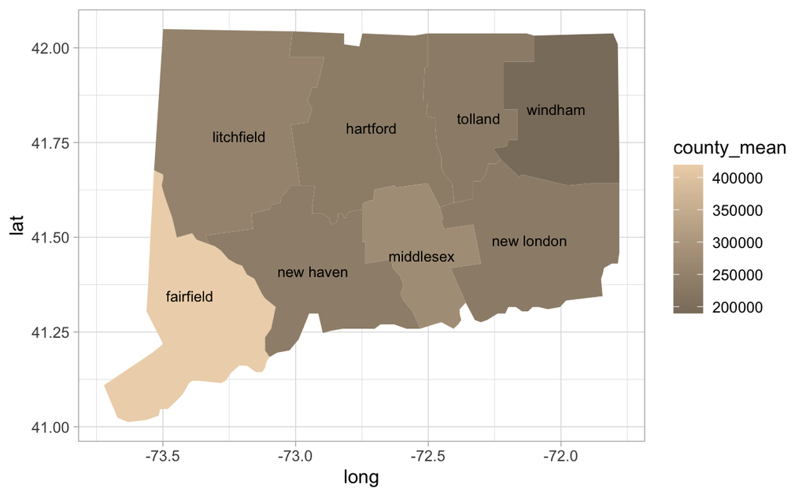

```r
ggplot(mapping, aes(x = long, y = lat)) +
  geom_polygon(aes(fill = county_mean, group = subregion)) +
  geom_text(data = county_names, aes(long, lat, label = subregion), size =3) +
  scale_fill_gradient(low = "bisque4", high = "bisque2") +
  theme_light()
```

- Here we can get a visualization of where in Connecticut (grouped by county) property values are the highest

## Change in mean `sale_price`

**Create of object of mean `sale price` for each town in 2006**

```r
mean_2006 <- connecticut %>%
  group_by(town, year) %>%
  select(year,
         sale_price,
         town) %>%
  summarize(mean_3 = mean(sale_price)) %>%
  filter(year == "2006-01-01")
```

**Create of object of mean `sale price` for each town in 2018**

```r
mean_2018 <- connecticut %>%
  group_by(town, year) %>%
  select(year,
         sale_price,
         town) %>%
  summarize(mean_3 = mean(sale_price)) %>%
  filter(year == "2018-01-01")
```

**View objects `mean_2006` and `mean_2018`**

```r
mean_2006
```

```
# A tibble: 130 × 3
# Groups:   town [130]
   town        year        mean_3
   <chr>       <date>       <dbl>
 1 Ansonia     2006-01-01 240118.
 2 Ashford     2006-01-01 236024.
 3 Avon        2006-01-01 412245.
 4 Barkhamsted 2006-01-01 268300
 5 Berlin      2006-01-01 271868.
 6 Bethany     2006-01-01 377326.
 7 Bethel      2006-01-01 340494.
 8 Bethlehem   2006-01-01 289000.
 9 Bloomfield  2006-01-01 305865.
10 Bolton      2006-01-01 286017.
# … with 120 more rows
```

```r
mean_2018
```

```
# A tibble: 168 × 3
# Groups:   town [168]
   town         year        mean_3
   <chr>        <date>       <dbl>
 1 Andover      2018-01-01 236506.
 2 Ansonia      2018-01-01 197108.
 3 Ashford      2018-01-01 187244.
 4 Avon         2018-01-01 389546.
 5 Barkhamsted  2018-01-01 301730.
 6 Beacon Falls 2018-01-01 238719.
 7 Berlin       2018-01-01 254156.
 8 Bethany      2018-01-01 373936.
 9 Bethel       2018-01-01 325866.
10 Bethlehem    2018-01-01 311912.
# … with 158 more rows
```

**Join `mean_2006` and `mean_2018` and create new column `delta_mean` and `c_mean`**

```r
combined <- mean_2006 %>%
  left_join(mean_2018, by = "town") %>%
  mutate(delta_mean = mean_3.y - mean_3.x) %>%
  mutate(c_mean = (mean_3.y - mean_3.x)/mean_3.x)
combined
```

```
# A tibble: 130 × 7
# Groups:   town [130]
   town    year.x     mean_3.x year.y     mean_3.y delta_mean   c_mean
   <chr>   <date>        <dbl> <date>        <dbl>      <dbl>    <dbl>
 1 Ansonia 2006-01-01  240118. 2018-01-01  197108.    -43010. -0.179
 2 Ashford 2006-01-01  236024. 2018-01-01  187244.    -48780. -0.207
 3 Avon    2006-01-01  412245. 2018-01-01  389546.    -22699. -0.0551
 4 Barkha… 2006-01-01  268300  2018-01-01  301730.     33430.  0.125
 5 Berlin  2006-01-01  271868. 2018-01-01  254156.    -17712. -0.0651
 6 Bethany 2006-01-01  377326. 2018-01-01  373936.     -3390. -0.00898
 7 Bethel  2006-01-01  340494. 2018-01-01  325866.    -14628. -0.0430
 8 Bethle… 2006-01-01  289000. 2018-01-01  311912.     22913.  0.0793
 9 Bloomf… 2006-01-01  305865. 2018-01-01  213458.    -92406. -0.302
10 Bolton  2006-01-01  286017. 2018-01-01  271425.    -14592. -0.0510
# … with 120 more rows
```

**Rename columns in `combined`**

```r
combined <- rename(combined,
                   "mean_06" = "mean_3.x",
                   "mean_18" = "mean_3.y")
```

**Remove unnecessary columns**

```r
combined <-
  select(combined,
         "mean_06",
         "mean_18",
         "delta_mean",
         "c_mean",
         "town")
```

**Create object of the six towns with highest change in mean sale price (%)**

```r
delta_top_6 <- combined %>%
  arrange(desc(c_mean)) %>%
  filter(c_mean > .14)
delta_top_6
```

```
# A tibble: 6 × 5
# Groups:   town [6]
  mean_06 mean_18 delta_mean c_mean town
    <dbl>   <dbl>      <dbl>  <dbl> <chr>
1 216725  285550      68825   0.318 Franklin
2 386750  481049.     94299.  0.244 Sharon
3 436000  528995.     92995.  0.213 Salisbury
4 273850  324583.     50733.  0.185 Colebrook
5 248727. 289751.     41024.  0.165 Chester
6 298083. 341824.     43740.  0.147 Morris
```

**Create vector of top 6**

```r
delta_top_6b <- delta_top_6$town
```

**Display top 6**

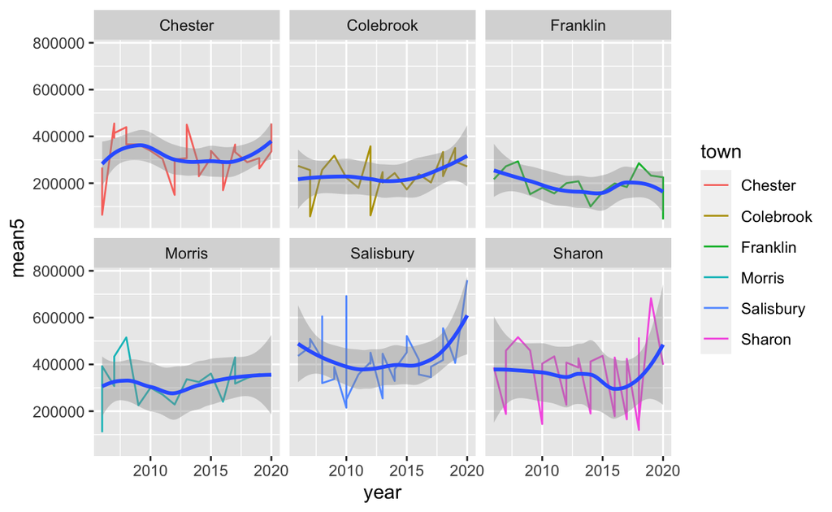

```r
connecticut %>%
  group_by(town, year, residential_type) %>%
  summarise(mean5 = mean(sale_price)) %>%
  filter(town %in% delta_top_6b) %>%
  ggplot(aes(x = year,
             y = mean5)) +
  geom_line(aes(color = town)) +
  geom_smooth() +
  facet_wrap(vars(town))
```

- While this graphic is not very revealing overall, it did reveal something interesting.
- Franklin is very small, there are only 175 observations over 12 years of data. Looking into Franklin further, I learned it is town of only 1900 people (2010). I realized that small towns are going to have potentially unreliable data.
- As a result, I will either group by county or filter out towns with very low observations.

## Status Summary

- What is missing (if anything) from your analysis process so far?
  - After looking over some of the previous students’ final projects I think my analysis is missing some general focus. It is almost all exploratory analysis currently. I think I need to focus on answering the specific research questions;
  - Where are property values increasing the most?
  - For what types of properties are the values increasing the fastest?
  - Where, and of what type of property should a prospective buyer buy?
- What conclusions can you make about your research questions at this point?
  - I cannot make a lot of conclusions about my research questions at this point.
  - I can say that the rate of change of sale price of the residential types appears different.
  - I can say that sale price in different towns is changing at different rates.
  - I cannot say definitively where the prices are increasing the fastest.
- What do you think the naive reader would need to fully understand your graphs?
  - I think the graphs that I have made would be mostly clear to the naive reader.
  - One exception would be what the lines on a geom_smooth() represent. I will need to clear that up
  - Unfortunately, I am not sure some of my graphs are very useful towards answering the research questions. Many are used to justify data wrangling or in pursuit of the research question but not in actually answering the question. This relates to focus and I will probably be able to edit out anything superfluous as I continue to work on the project.
- Is there anything you want to answer with your dataset, but can’t?
  - Currently, I do not think there are any questions that I want to answer but cannot. I am not sure if that will change as I continue.
  - I wanted create a heat map with different towns but have unable to find a data set that contains the necessary data. I was able to create one with counties but that was not my original goal. It’s not really a question I can’t answer, just a graphic I can’t display.